# Computing Cheatsheet

Engineering Statistics I (MA223)

This document provides a list of the code most commonly used in the course. There may be times, especially for your capstone projects, in which you want to move beyond what we discuss in the class. If you are interested, I would encourage you to look at the `ggplot2` package and would guide you toward the [Ggplot Cheat Sheet](https://www.rstudio.com/wp-content/uploads/2015/03/ggplot2-cheatsheet.pdf).

Throughout this document, we will be making use of the following `mtcars` dataset available with all R installations. More information can be found about the variables in this dataset by typing `?mtcars` into your R console or typing `mtcars` into the help search box in RStudio. Here are the first few records of the dataset:

```
##                      mpg cyl  disp  hp drat    wt  qsec vs am gear carb
## Mazda RX4           21.0   6 160.0 110 3.90 2.620 16.46  0  1    4    4
## Mazda RX4 Wag       21.0   6 160.0 110 3.90 2.875 17.02  0  1    4    4
## Datsun 710          22.8   4 108.0  93 3.85 2.320 18.61  1  1    4    1
## Hornet 4 Drive      21.4   6 258.0 110 3.08 3.215 19.44  1  0    3    1
## Hornet Sportabout   18.7   8 360.0 175 3.15 3.440 17.02  0  0    3    2
## Valiant             18.1   6 225.0 105 2.76 3.460 20.22  1  0    3    1
## Duster 360          14.3   8 360.0 245 3.21 3.570 15.84  0  0    3    4
## Merc 240D           24.4   4 146.7  62 3.69 3.190 20.00  1  0    4    2
## Merc 230            22.8   4 140.8  95 3.92 3.150 22.90  1  0    4    2
## Merc 280            19.2   6 167.6 123 3.92 3.440 18.30  1  0    4    4
## Merc 280C           17.8   6 167.6 123 3.92 3.440 18.90  1  0    4    4
## Merc 450SE          16.4   8 275.8 180 3.07 4.070 17.40  0  0    3    3
## Merc 450SL          17.3   8 275.8 180 3.07 3.730 17.60  0  0    3    3
## Merc 450SLC         15.2   8 275.8 180 3.07 3.780 18.00  0  0    3    3
## Cadillac Fleetwood  10.4   8 472.0 205 2.93 5.250 17.98  0  0    3    4
## Lincoln Continental 10.4   8 460.0 215 3.00 5.424 17.82  0  0    3    4
## Chrysler Imperial   14.7   8 440.0 230 3.23 5.345 17.42  0  0    3    4
## Fiat 128            32.4   4  78.7  66 4.08 2.200 19.47  1  1    4    1
## Honda Civic         30.4   4  75.7  52 4.93 1.615 18.52  1  1    4    2
## Toyota Corolla      33.9   4  71.1  65 4.22 1.835 19.90  1  1    4    1
## Toyota Corona       21.5   4 120.1  97 3.70 2.465 20.01  1  0    3    1
## Dodge Challenger    15.5   8 318.0 150 2.76 3.520 16.87  0  0    3    2
## AMC Javelin         15.2   8 304.0 150 3.15 3.435 17.30  0  0    3    2
## Camaro Z28          13.3   8 350.0 245 3.73 3.840 15.41  0  0    3    4
## Pontiac Firebird    19.2   8 400.0 175 3.08 3.845 17.05  0  0    3    2
## Fiat X1-9           27.3   4  79.0  66 4.08 1.935 18.90  1  1    4    1
## Porsche 914-2       26.0   4 120.3  91 4.43 2.140 16.70  0  1    5    2
## Lotus Europa        30.4   4  95.1 113 3.77 1.513 16.90  1  1    5    2
## Ford Pantera L      15.8   8 351.0 264 4.22 3.170 14.50  0  1    5    4
## Ferrari Dino        19.7   6 145.0 175 3.62 2.770 15.50  0  1    5    6
## Maserati Bora       15.0   8 301.0 335 3.54 3.570 14.60  0  1    5    8
## Volvo 142E          21.4   4 121.0 109 4.11 2.780 18.60  1  1    4    2
```

As you progress through the following examples, remember that R is *case sensitive*.

## Packages

Throughout the course we will be using a standard suite of packages. The top of any R Notebook you produce for this course should have the following code. This will typically be provided to you, and you should not have a need to alter it.

```r
library(car)       # special functions for summarizing models
library(tidyverse) # plotting and data manipulation
library(stringr)   # working with character strings
library(broom)     # making model output pretty
source(str_c("https://raw.githubusercontent.com/reyesem/",
             "MA223-Additional-Files/master/BootstrapFunctions.R")) # bootstrap
```

## Data Manipulation

Data is rarely perfect when we first obtain it. Often times, we will need to make changes. There are a few tasks which are performed regularly:

- `mutate()`: manipulate variables or make transformations.
- `arrange()`: order (sort) the data according to specific variables.
- `filter()`: filter the dataset to retain only a specified subset.

```r
mtcars <- mtcars %>%
  mutate(Gallons_per_Mile = 1/mpg)
```

```
##     mpg cyl  disp  hp drat    wt  qsec vs am gear carb Gallons_per_Mile
## 1  21.0   6 160.0 110 3.90 2.620 16.46  0  1    4    4       0.04761905
## 2  21.0   6 160.0 110 3.90 2.875 17.02  0  1    4    4       0.04761905
## 3  22.8   4 108.0  93 3.85 2.320 18.61  1  1    4    1       0.04385965
## 4  21.4   6 258.0 110 3.08 3.215 19.44  1  0    3    1       0.04672897
## 5  18.7   8 360.0 175 3.15 3.440 17.02  0  0    3    2       0.05347594
## 6  18.1   6 225.0 105 2.76 3.460 20.22  1  0    3    1       0.05524862
## 7  14.3   8 360.0 245 3.21 3.570 15.84  0  0    3    4       0.06993007
## 8  24.4   4 146.7  62 3.69 3.190 20.00  1  0    4    2       0.04098361
## 9  22.8   4 140.8  95 3.92 3.150 22.90  1  0    4    2       0.04385965
## 10 19.2   6 167.6 123 3.92 3.440 18.30  1  0    4    4       0.05208333
## 11 17.8   6 167.6 123 3.92 3.440 18.90  1  0    4    4       0.05617978
## 12 16.4   8 275.8 180 3.07 4.070 17.40  0  0    3    3       0.06097561
## 13 17.3   8 275.8 180 3.07 3.730 17.60  0  0    3    3       0.05780347
## 14 15.2   8 275.8 180 3.07 3.780 18.00  0  0    3    3       0.06578947
```

[output cut: 18 more lines]

```r
mtcars <- mtcars %>%
  arrange()
```

```
##     mpg cyl  disp  hp drat    wt  qsec vs am gear carb Gallons_per_Mile
## 1  21.0   6 160.0 110 3.90 2.620 16.46  0  1    4    4       0.04761905
## 2  21.0   6 160.0 110 3.90 2.875 17.02  0  1    4    4       0.04761905
## 3  22.8   4 108.0  93 3.85 2.320 18.61  1  1    4    1       0.04385965
## 4  21.4   6 258.0 110 3.08 3.215 19.44  1  0    3    1       0.04672897
## 5  18.7   8 360.0 175 3.15 3.440 17.02  0  0    3    2       0.05347594
## 6  18.1   6 225.0 105 2.76 3.460 20.22  1  0    3    1       0.05524862
## 7  14.3   8 360.0 245 3.21 3.570 15.84  0  0    3    4       0.06993007
## 8  24.4   4 146.7  62 3.69 3.190 20.00  1  0    4    2       0.04098361
## 9  22.8   4 140.8  95 3.92 3.150 22.90  1  0    4    2       0.04385965
## 10 19.2   6 167.6 123 3.92 3.440 18.30  1  0    4    4       0.05208333
## 11 17.8   6 167.6 123 3.92 3.440 18.90  1  0    4    4       0.05617978
## 12 16.4   8 275.8 180 3.07 4.070 17.40  0  0    3    3       0.06097561
## 13 17.3   8 275.8 180 3.07 3.730 17.60  0  0    3    3       0.05780347
## 14 15.2   8 275.8 180 3.07 3.780 18.00  0  0    3    3       0.06578947
```

[output cut: 18 more lines]

If we only want to consider automatic transmissions, and perhaps save those in a separate dataset, we can use `filter()`:

```r
automatic.only <- mtcars %>%
  filter(am == 0)
```

When making comparisons, `==` is asking “are you equal?” We keep the “yes/true” statements. The original `mtcars` dataset is not altered; it remains unchanged. Instead, we have taken it, filtered it down, and then stored the results in `automatic.only` (shown below).

```
##     mpg cyl  disp  hp drat    wt  qsec vs am gear carb Gallons_per_Mile
## 1  21.4   6 258.0 110 3.08 3.215 19.44  1  0    3    1       0.04672897
## 2  18.7   8 360.0 175 3.15 3.440 17.02  0  0    3    2       0.05347594
## 3  18.1   6 225.0 105 2.76 3.460 20.22  1  0    3    1       0.05524862
## 4  14.3   8 360.0 245 3.21 3.570 15.84  0  0    3    4       0.06993007
## 5  24.4   4 146.7  62 3.69 3.190 20.00  1  0    4    2       0.04098361
## 6  22.8   4 140.8  95 3.92 3.150 22.90  1  0    4    2       0.04385965
## 7  19.2   6 167.6 123 3.92 3.440 18.30  1  0    4    4       0.05208333
## 8  17.8   6 167.6 123 3.92 3.440 18.90  1  0    4    4       0.05617978
## 9  16.4   8 275.8 180 3.07 4.070 17.40  0  0    3    3       0.06097561
## 10 17.3   8 275.8 180 3.07 3.730 17.60  0  0    3    3       0.05780347
## 11 15.2   8 275.8 180 3.07 3.780 18.00  0  0    3    3       0.06578947
## 12 10.4   8 472.0 205 2.93 5.250 17.98  0  0    3    4       0.09615385
## 13 10.4   8 460.0 215 3.00 5.424 17.82  0  0    3    4       0.09615385
## 14 14.7   8 440.0 230 3.23 5.345 17.42  0  0    3    4       0.06802721
## 15 21.5   4 120.1  97 3.70 2.465 20.01  1  0    3    1       0.04651163
## 16 15.5   8 318.0 150 2.76 3.520 16.87  0  0    3    2       0.06451613
## 17 15.2   8 304.0 150 3.15 3.435 17.30  0  0    3    2       0.06578947
## 18 13.3   8 350.0 245 3.73 3.840 15.41  0  0    3    4       0.07518797
## 19 19.2   8 400.0 175 3.08 3.845 17.05  0  0    3    2       0.05208333
```

When we work with categorical variables, we often want to keep the values (or group labels) as something very readable. In order to do this, we may need to recode what is there. Consider the variable `am` (transmission type). It is currently a 0/1 variable, which is not extremely clear that 1 represents manual transmission. We alter this using `mutate()`.

```r
mtcars <- mtcars %>%
  mutate(am = recode(am,
                     `0` = "automatic",
                     `1` = "manual"))
```

```
##     mpg cyl  disp  hp drat    wt  qsec vs        am gear carb
## 1  21.0   6 160.0 110 3.90 2.620 16.46  0    manual    4    4
## 2  21.0   6 160.0 110 3.90 2.875 17.02  0    manual    4    4
## 3  22.8   4 108.0  93 3.85 2.320 18.61  1    manual    4    1
## 4  21.4   6 258.0 110 3.08 3.215 19.44  1 automatic    3    1
## 5  18.7   8 360.0 175 3.15 3.440 17.02  0 automatic    3    2
## 6  18.1   6 225.0 105 2.76 3.460 20.22  1 automatic    3    1
## 7  14.3   8 360.0 245 3.21 3.570 15.84  0 automatic    3    4
## 8  24.4   4 146.7  62 3.69 3.190 20.00  1 automatic    4    2
## 9  22.8   4 140.8  95 3.92 3.150 22.90  1 automatic    4    2
## 10 19.2   6 167.6 123 3.92 3.440 18.30  1 automatic    4    4
## 11 17.8   6 167.6 123 3.92 3.440 18.90  1 automatic    4    4
## 12 16.4   8 275.8 180 3.07 4.070 17.40  0 automatic    3    3
## 13 17.3   8 275.8 180 3.07 3.730 17.60  0 automatic    3    3
## 14 15.2   8 275.8 180 3.07 3.780 18.00  0 automatic    3    3
```

[output cut: 51 more lines]

## Numerical Summaries

A quick summary (though not always useful) of all the variables in a dataset can be obtained by using the `summary()` function.

```r
summary(mtcars)
```

```
##       mpg             cyl             disp             hp
##  Min.   :10.40   Min.   :4.000   Min.   : 71.1   Min.   : 52.0
##  1st Qu.:15.43   1st Qu.:4.000   1st Qu.:120.8   1st Qu.: 96.5
##  Median :19.20   Median :6.000   Median :196.3   Median :123.0
##  Mean   :20.09   Mean   :6.188   Mean   :230.7   Mean   :146.7
##  3rd Qu.:22.80   3rd Qu.:8.000   3rd Qu.:326.0   3rd Qu.:180.0
##  Max.   :33.90   Max.   :8.000   Max.   :472.0   Max.   :335.0
##       drat             wt             qsec             vs
##  Min.   :2.760   Min.   :1.513   Min.   :14.50   Min.   :0.0000
##  1st Qu.:3.080   1st Qu.:2.581   1st Qu.:16.89   1st Qu.:0.0000
##  Median :3.695   Median :3.325   Median :17.71   Median :0.0000
##  Mean   :3.597   Mean   :3.217   Mean   :17.85   Mean   :0.4375
##  3rd Qu.:3.920   3rd Qu.:3.610   3rd Qu.:18.90   3rd Qu.:1.0000
##  Max.   :4.930   Max.   :5.424   Max.   :22.90   Max.   :1.0000
##       am                 gear            carb       Gallons_per_Mile
##  Length:32          Min.   :3.000   Min.   :1.000   Min.   :0.02950
##  Class :character   1st Qu.:3.000   1st Qu.:2.000   1st Qu.:0.04386
##  Mode  :character   Median :4.000   Median :2.000   Median :0.05208
##                     Mean   :3.688   Mean   :2.812   Mean   :0.05423
##                     3rd Qu.:4.000   3rd Qu.:4.000   3rd Qu.:0.06483
##                     Max.   :5.000   Max.   :8.000   Max.   :0.09615
```

If you want to preserve the output of the dataset, we can use the `summarise()` function.

```r
mtcars %>%
  summarise(Mean_MPG = mean(mpg),
            Pct_manual = mean(am=="manual"))
```

```
##   Mean_MPG Pct_manual
## 1 20.09062    0.40625
```

What is nice about the `summarise()` function is that it works well after grouping the dataset. The following code breaks the dataset into groups based on the number of cylinders and then computes the summaries.

```r
mtcars %>%
  group_by(cyl) %>%
  summarise(Mean_MPG = mean(mpg),
            Pct_manual = mean(am=="manual"))
```

```
## # A tibble: 3 x 3
##     cyl Mean_MPG Pct_manual
##   <dbl>    <dbl>      <dbl>
## 1     4 26.66364  0.7272727
## 2     6 19.74286  0.4285714
## 3     8 15.10000  0.1428571
```

## Graphics

When examining the distribution of a categorical variable, we will primarily use a bar chart. The variable you want to summarize goes on the x-axis; you must also specify the data and it is safe to say `geom = "bar"` to specify a bar chart (though this is typically the default). Labels can also be passed using `xlab =` and `ylab =`. There is not much customization here; you need to use `ggplot()` to get more custom graphics, but that is beyond the scope of what I will expect.

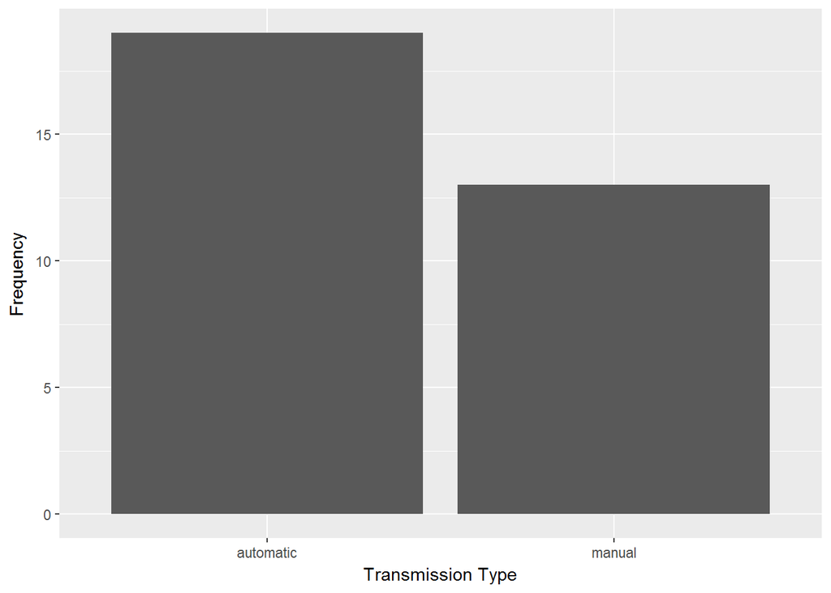

```r
qplot(x = am,
      data = mtcars,
      geom = "bar",
      xlab = "Transmission Type",
      ylab = "Frequency")
```

If you have multiple categorical variables, consider using additional aesthetics. All categorical variables need to either be “factors” or “character strings” (wrapped in quotations `""`). If they are entered as numbers, R will not know how to treat them. For example, if we want a bar chart comparing transmission types for cars with varying number of cylinders, we can ust the following code.

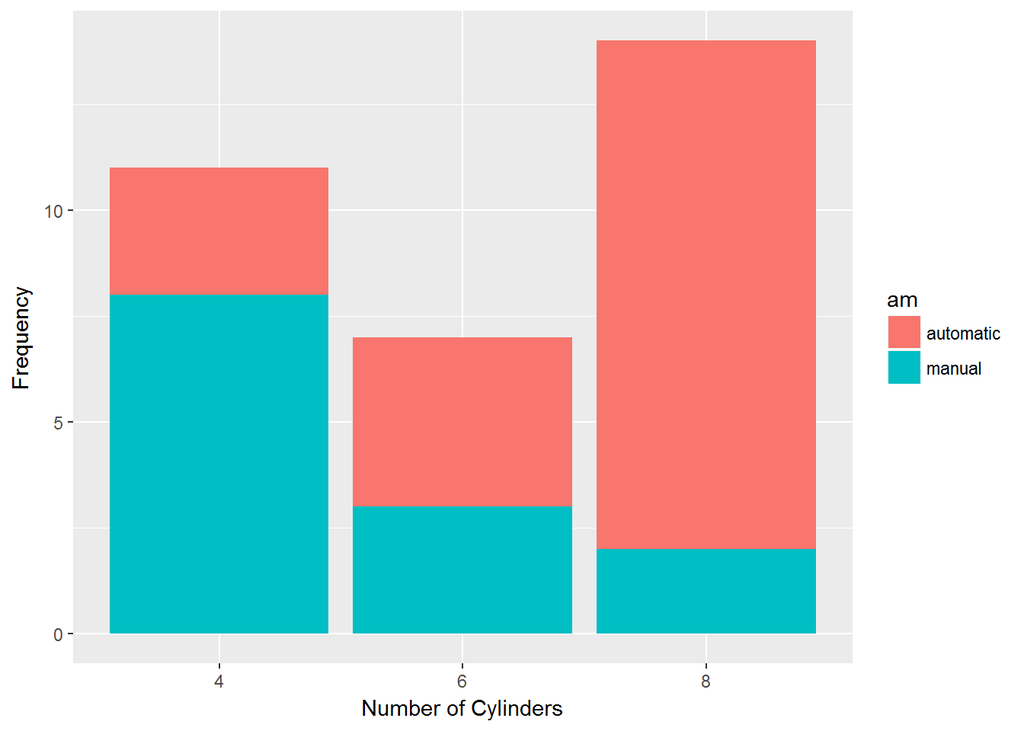

```r
# Recode the number of cylinders
#  The factor() function turns the variable into a categorical one
mtcars <- mtcars %>%
  mutate(cyl = factor(cyl))

qplot(x = cyl,
      fill = am,
      data = mtcars,
      xlab = "Number of Cylinders",
      ylab = "Frequency")
```

The above also illustrates the importance of nice naming conventions so that the label on the legend is appropriate. Labels can be added easily with the `labs()` function, but past this, we will not do much customization.

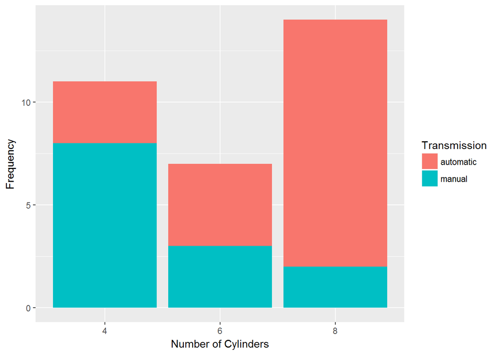

```r
qplot(x = cyl,
      fill = am,
      data = mtcars) +
  labs(x = "Number of Cylinders",
       y = "Frequency",
       fill = "Transmission")
```

When looking at the distribution of a single variable, we might use a histogram or a density plot. The histogram requires that you carefully specify the width of each bin. The density plot is a smoothed version of the histogram but will not work well without a sufficiently large amount of data. For each, specify the variable to be placed along the x-axis and then the type of plot is governed by `geom = "plot-type"`.

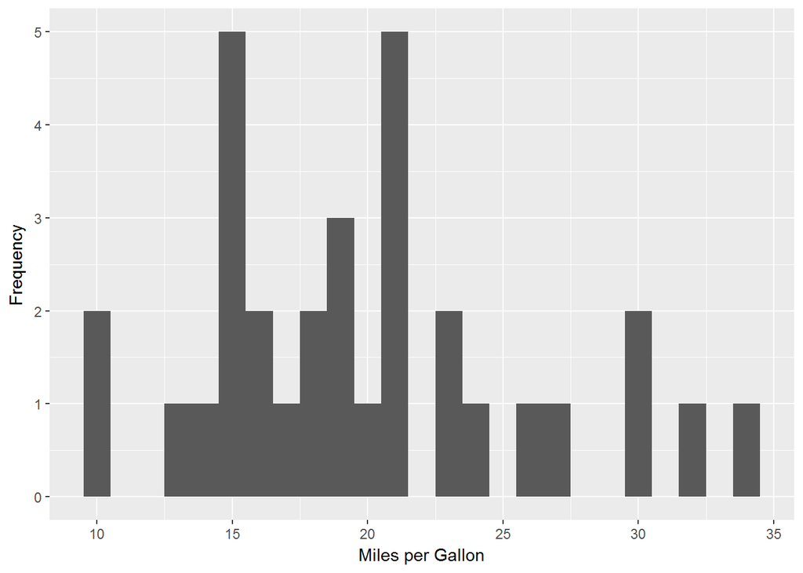

```r
qplot(x = mpg,
      data = mtcars,
      geom = "histogram",
      binwidth = 1,
      xlab = "Miles per Gallon",
      ylab = "Frequency")
```

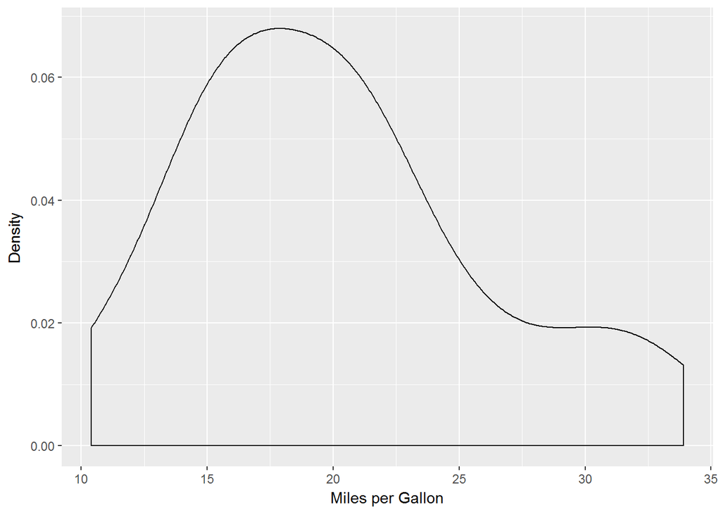

```r
qplot(x = mpg,
      data = mtcars,
      geom = "density",
      xlab = "Miles per Gallon",
      ylab = "Density")
```

If we are comparing a quantitative variable across levels of a categorical variable, we can consider side-by-side boxplots or violin plots.

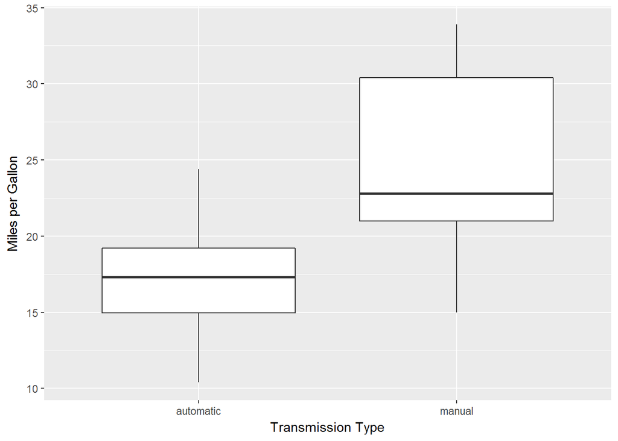

```r
qplot(y = mpg,
      x = am,
      data = mtcars,
      geom = "boxplot",
      xlab = "Transmission Type",
      ylab = "Miles per Gallon")
```

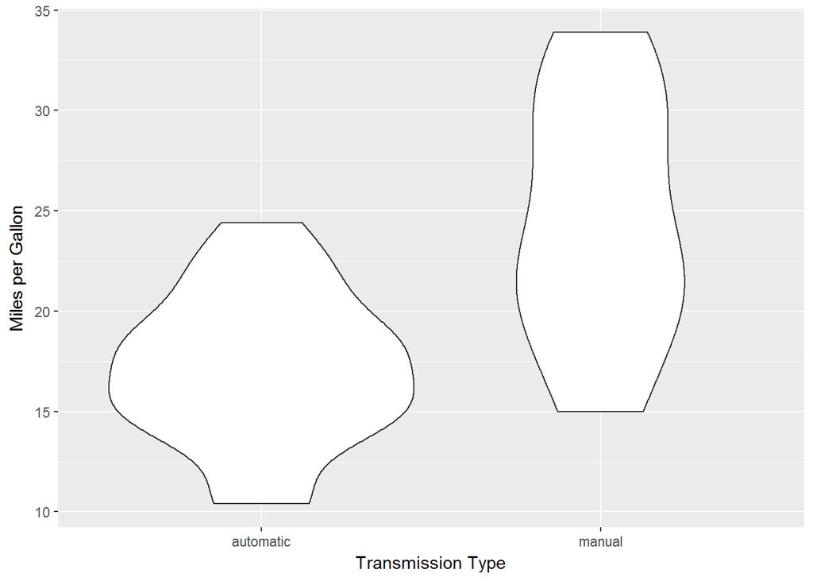

```r
qplot(y = mpg,
      x = am,
      data = mtcars,
      geom = "violin",
      xlab = "Transmission Type",
      ylab = "Miles per Gallon")
```

We can also add additional aesthetics to make more comparisons.

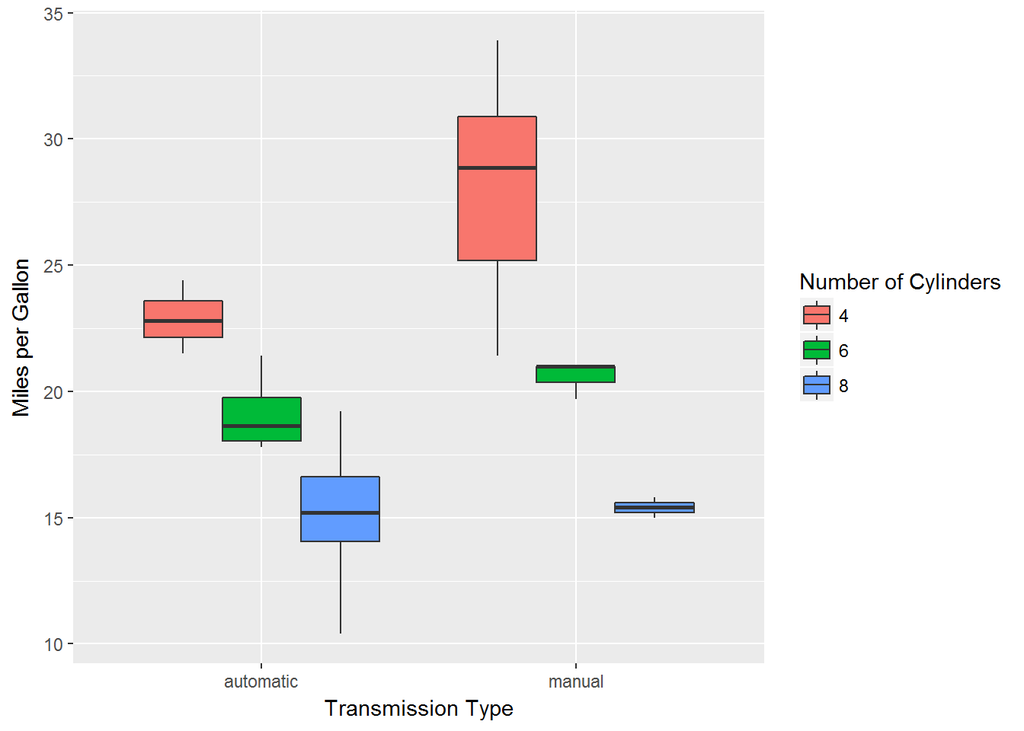

```r
qplot(y = mpg,
      x = am,
      fill = cyl,
      data = mtcars,
      geom = "boxplot") +
  labs(x = "Transmission Type",
       y = "Miles per Gallon",
       fill = "Number of Cylinders")
```

When examining the relationship between two quantitative variables, we can use a scatterplot.

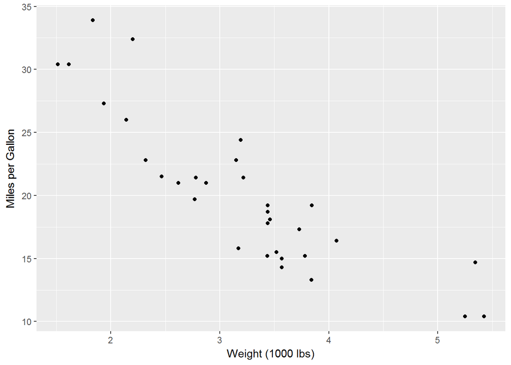

```r
qplot(y = mpg,
      x = wt,
      data = mtcars,
      ylab = "Miles per Gallon",
      xlab = "Weight (1000 lbs)",
      geom = "point")
```

Again, we can add more to this using additional aesthetics.

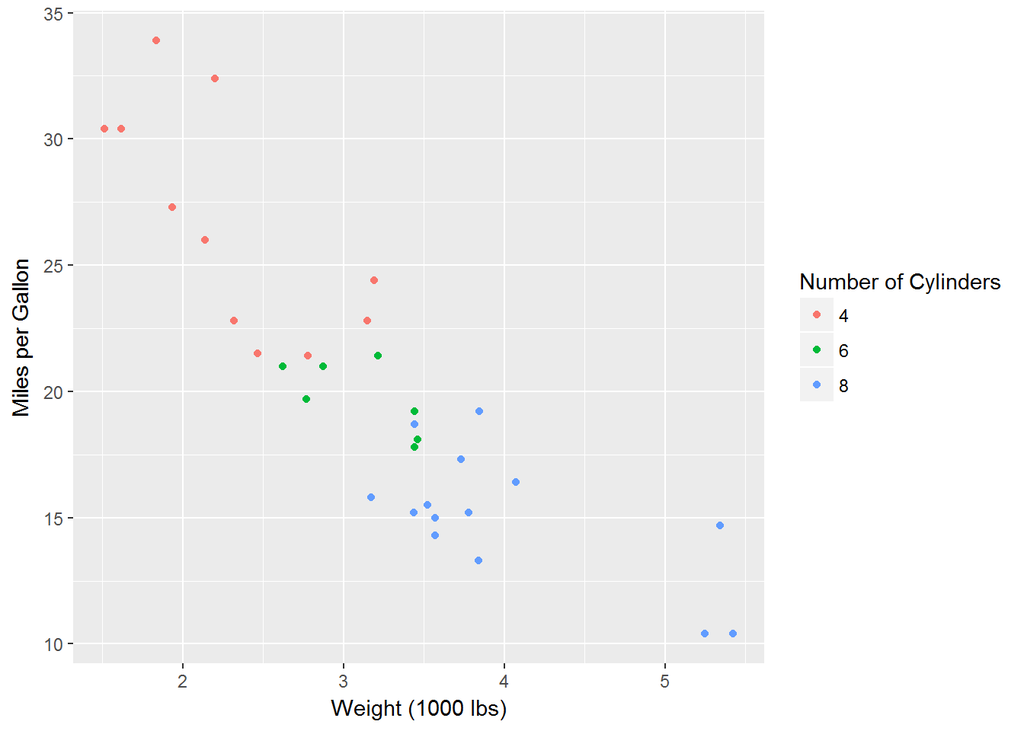

```r
qplot(y = mpg,
      x = wt,
      color = cyl,
      data = mtcars,
      geom = "point") +
  labs(x = "Weight (1000 lbs)",
       y = "Miles per Gallon",
       color = "Number of Cylinders")
```

If we are clever about layering aspects of a graphic, we can also include a smoothing line.

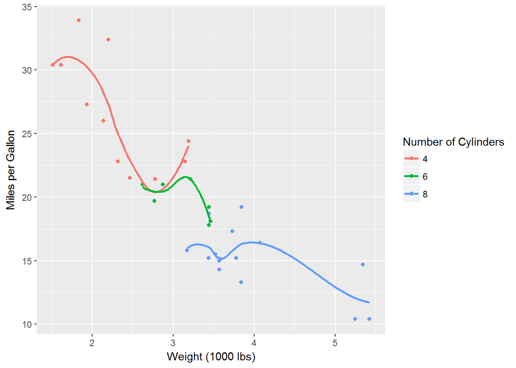

```r
qplot(y = mpg,
      x = wt,
      color = cyl,
      data = mtcars,
      geom = c("point", "smooth"),
      se = FALSE) +
  labs(x = "Weight (1000 lbs)",
       y = "Miles per Gallon",
       color = "Number of Cylinders")
```

## Models

We primarily work with two types of models in the course: ANOVA and regression models. Due to their connection, they are fit the same way. We simply examine the output differently. All models are specified with the `response ~ predictors` syntax using the `lm()` function.

An ANOVA model examining fuel efficiency across transmission types could be examined by

```r
anova.fit <- lm(mpg ~ am, data = mtcars)
Anova(anova.fit)
```

```
## Anova Table (Type II tests)
##
## Response: mpg
##           Sum Sq Df F value   Pr(>F)
## am        405.15  1   16.86 0.000285 ***
## Residuals 720.90 30
## ---
## Signif. codes:  0 '***' 0.001 '**' 0.01 '*' 0.05 '.' 0.1 ' ' 1
```

A linear model examining fuel efficiency and weight would be

```r
simple.fit <- lm(mpg ~ wt, data = mtcars)
tidy(simple.fit)
```

```
##          term  estimate std.error statistic      p.value
## 1 (Intercept) 37.285126  1.877627 19.857575 8.241799e-19
## 2          wt -5.344472  0.559101 -9.559044 1.293959e-10
```

A more complex linear model comes from adding additional terms using a `+` sign, and interactions specified using a `:`.

```r
multiple.fit <- lm(mpg ~ wt + am + wt:am, data = mtcars)
tidy(multiple.fit)
```

```
##          term  estimate std.error statistic      p.value
## 1 (Intercept) 31.416055 3.0201093 10.402291 4.001043e-11
## 2          wt -3.785908 0.7856478 -4.818836 4.551182e-05
## 3    ammanual 14.878423 4.2640422  3.489277 1.621034e-03
## 4 wt:ammanual -5.298360 1.4446993 -3.667449 1.017148e-03
```

If you need residuals for constructing plots, we can create a new dataset which includes those using the `augment()` function; the residuals will be stored in the variable `.resid` and the predicted values in `.fitted`.

```r
mtcars.aug <- augment(multiple.fit)
```

```
##     mpg    wt        am  .fitted   .se.fit       .resid       .hat
## 1  21.0 2.620    manual 22.49370 0.7620445 -1.493695675 0.08648548
## 2  21.0 2.875    manual 20.17721 0.9126725  0.822792671 0.12405447
## 3  22.8 2.320    manual 25.21898 0.7271017 -2.418976083 0.07873591
## 4  21.4 3.215 automatic 19.24436 0.7367275  2.155637322 0.08083441
## 5  18.7 3.440 automatic 18.39253 0.6482022  0.307466517 0.06257537
## 6  18.1 3.460 automatic 18.31682 0.6421002 -0.216815332 0.06140278
## 7  14.3 3.570 automatic 17.90037 0.6146669 -3.600365503 0.05626809
## 8  24.4 3.190 automatic 19.33901 0.7484969  5.060989634 0.08343773
## 9  22.8 3.150 automatic 19.49045 0.7679978  3.309553333 0.08784205
## 10 19.2 3.440 automatic 18.39253 0.6482022  0.807466517 0.06257537
## 11 17.8 3.440 automatic 18.39253 0.6482022 -0.592533483 0.06257537
## 12 16.4 4.070 automatic 16.00741 0.6398123  0.392588263 0.06096599
## 13 17.3 3.730 automatic 17.29462 0.5952576  0.005379702 0.05277064
## 14 15.2 3.780 automatic 17.10532 0.5945368 -1.905324922 0.05264292
```

[output cut: 51 more lines]

## Diagnostic Plots

The two diagnostic plots that may not be obvious given what we have discussed so far is a time-series plot of the residuals and a probability plot of the residuals. The time-series plot is constructed by layering components.

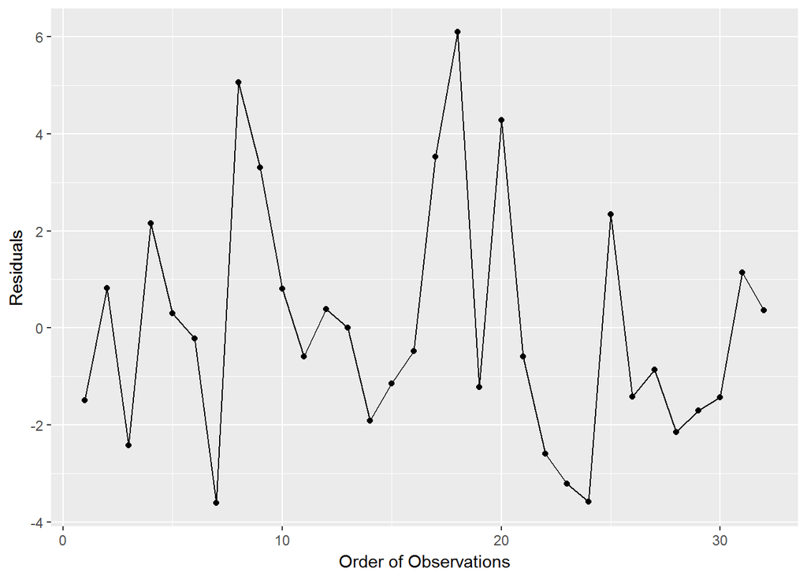

```r
qplot(x = seq_along(.resid),
      y = .resid,
      data = mtcars.aug,
      geom = c("line", "point"),
      xlab = "Order of Observations",
      ylab = "Residuals")
```

The probability plot is created using the following

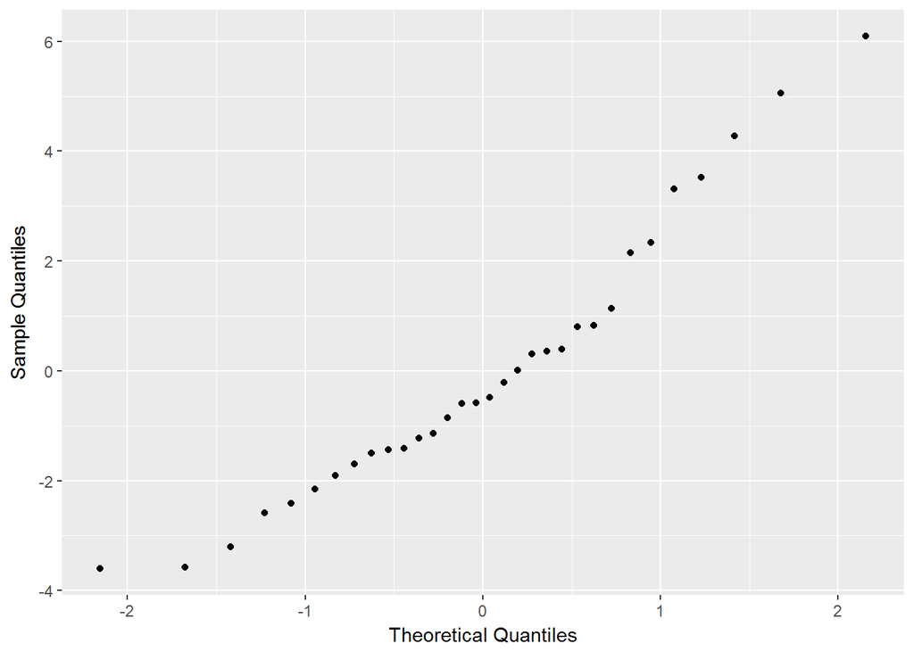

```r
qplot(sample = .resid,
      data = mtcars.aug,
      xlab = "Theoretical Quantiles",
      ylab = "Sample Quantiles",
      geom = "qq")
```

A plot of the residuals against the fitted values would be given by

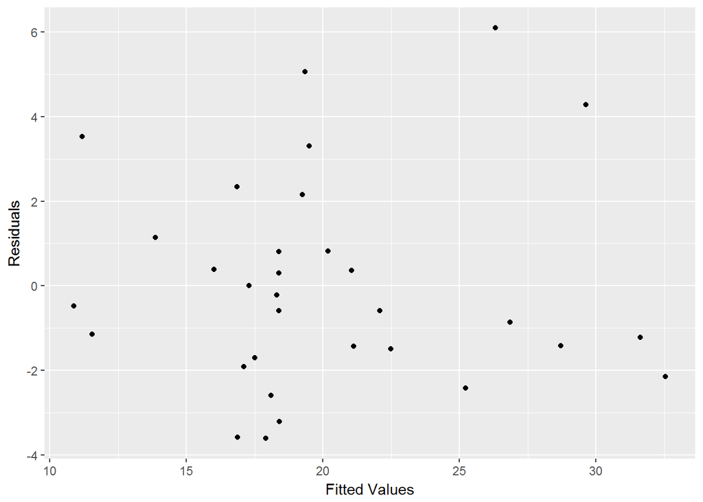

```r
qplot(x = .fitted,
      y = .resid,
      data = mtcars.aug,
      xlab = "Fitted Values",
      ylab = "Residuals")
```

## Bootstrapping

The most computational aspect of the course is *bootstrapping* a dataset to build an empirical model or to construct a null distribution. We will use the `boot_model()` function for bootstrapping. There are a couple of big things we need to think about with this function:

- `orig.model`: this is the model we are fitting and for which we either want to construct confidence intervals or a p-value.
- `null.model`: this is only important if you are looking at a particular p-value. This is the model which you would fit if the null model were true. Note that you have to bootstrap one p-value at a time.
- `constant.var`: an indicator of whether you want to assume constant variance (default = `TRUE`).
- `conf.level`: if you are making confidence intervals, the confidence level you want to use.

As an example, suppose we would like to compute 95% confidence intervals for the parameters of the following model:
$$(\text{MPG})_i = \beta_0 + \beta_1 (\text{Weight})_i + \beta_2 (\text{Manual Transmission})_i + \epsilon_i$$

This can be done with the following code

```r
# Original Fit
original.fit <- lm(mpg ~ wt + am, data = mtcars)

# Bootstrap
#  Remember to set seed to be repeatable.
set.seed(123)
boot.ci.distn <- boot_model(original.fit, conf.level = 95, constant.var = TRUE)

# Look at Results
boot.ci.distn
```

```
## 95% CI:
## # A tibble: 3 x 3
##          term       LCL       UCL
##         <chr>     <dbl>     <dbl>
## 1 (Intercept) 31.795916 42.782984
## 2    ammanual -2.781151  3.095325
## 3          wt -6.754002 -3.827443
##
##
##  Snippet of Distribution:
##           term   estimate std.error  statistic      p.value
## 1  (Intercept) 35.7987620 3.5817713  9.9947091 6.679574e-11
## 2           wt -5.1718043 0.9242694 -5.5955594 4.855904e-06
## 3     ammanual  0.7161092 1.8123742  0.3951221 6.956442e-01
## 4  (Intercept) 36.8051767 2.5632734 14.3586620 1.031163e-14
## 5           wt -5.0447157 0.6614479 -7.6267768 2.078295e-08
## 6     ammanual -0.6183893 1.2970149 -0.4767789 6.370928e-01
## 7  (Intercept) 34.3490501 2.4676823 13.9195591 2.272526e-14
## 8           wt -4.5084025 0.6367808 -7.0799910 8.658973e-08
## 9     ammanual -0.2756982 1.2486459 -0.2207978 8.267971e-01
## 10 (Intercept) 41.6907159 3.0388724 13.7191401 3.279864e-14
```

In addition to simply printing the results, we can also examine the entire distribution, but we need to be careful to do this for a particular estimate (say, the parameter for weight).

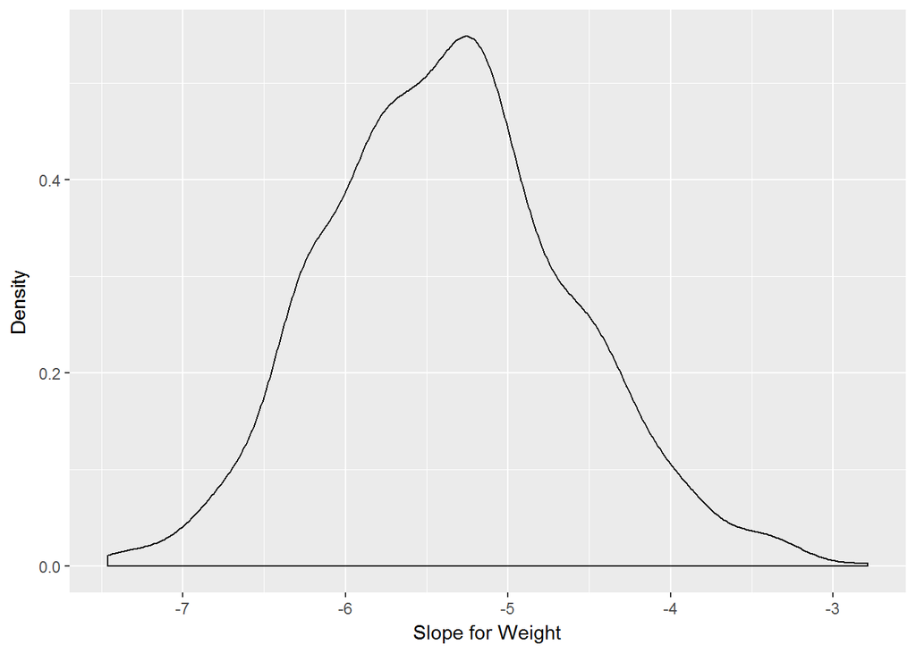

```r
plot.dat <- boot.ci.distn %>%
  filter(term=="wt")

qplot(x = estimate,
      data = plot.dat,
      geom = "density",
      xlab = "Slope for Weight",
      ylab = "Density")
```

If we want to construct a p-value for the hypotheses
$$H_0: \beta_2 = 0 \quad \text{vs.} \quad H_1: \beta_2 \neq 0$$

testing whether the fuel efficiency is related to the manual transmission after accounting for the weight of the vehicle. In order to do this, we need to think about what the reduced model implies — namely, that the only predictor in the model is weight. The following code fits the original model, the reduced model and then bootstraps to compute the p-value. Suppose further we are not willing to make the constant variance assumption.

```r
# Original Fit
original.fit <- lm(mpg ~ wt + am, data = mtcars)

# Null Model
reduced.fit <- lm(mpg ~ wt, data = mtcars)

# Bootstrap
set.seed(123)
boot.p.distn <- boot_model(original.fit,
                           null.model = reduced.fit,
                           constant.var = FALSE)

boot.p.distn
```

```
## p-value:
## [1] 0.992
##
##
##  Snippet of Distribution:
## # A tibble: 10 x 6
##    res.df      rss    df      sumsq  statistic    p.value
##     <dbl>    <dbl> <dbl>      <dbl>      <dbl>      <dbl>
##  1     29 316.5336     1  1.6006071 0.14664352 0.70455643
##  2     29 210.5315     1 12.0036640 1.65346364 0.20866115
##  3     29 310.3516     1  2.1301844 0.19904956 0.65880265
##  4     29 301.3438     1  0.5452699 0.05247438 0.82042014
##  5     29 225.9100     1 12.3797575 1.58918568 0.21749129
##  6     29 202.2272     1  0.3139135 0.04501614 0.83345857
##  7     29 135.2370     1 26.6168452 5.70767237 0.02361646
##  8     29 177.7969     1  5.5033278 0.89763367 0.35124554
##  9     29 244.8160     1  0.2480274 0.02938042 0.86509407
## 10     29 240.6689     1 14.4380483 1.73974896 0.19749159
```

Using the results, we can actually examine the entire null distribution, if desired.

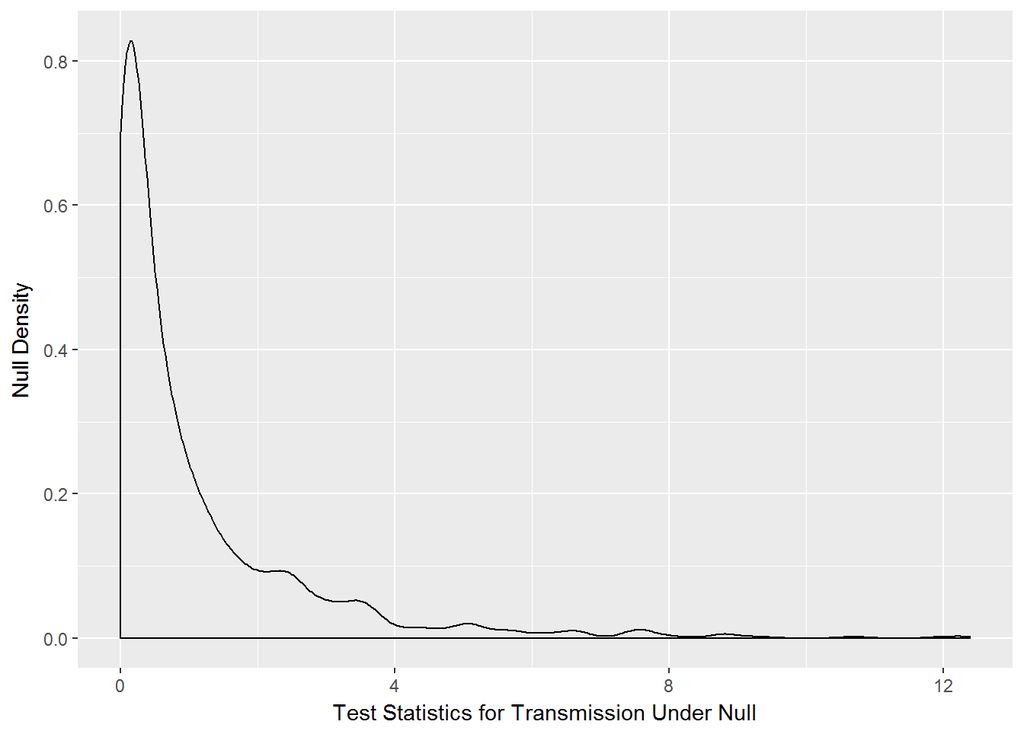

```r
qplot(x = statistic,
      data = boot.p.distn,
      geom = "density",
      xlab = "Test Statistics for Transmission Under Null",
      ylab = "Null Density")
```